# R Notebook

```r
library(caret)
library(dplyr)
```

```r
library(ggplot2)
library(tidyr)
library(lattice)

treino <- read.csv("train.csv", encoding="UTF-8")
teste <- read.csv("test.csv", encoding="UTF-8")
submission <- read.csv("submission.csv", encoding = "UTF-8")

summary(treino)
```

```
##        ID                                       nome      numero_cadidato
##  Min.   :1.000e+10   ADRIANA RODRIGUES DE OLIVEIRA:   2   Min.   :1000
##  1st Qu.:1.200e+11   ALEXANDRE GOMES FERREIRA     :   2   1st Qu.:1520
##  Median :1.900e+11   ANTONIO CARLOS LUCAS         :   2   Median :2881
##  Mean   :1.661e+11   ANTONIO FERREIRA PINTO       :   2   Mean   :3302
##  3rd Qu.:2.400e+11   CARLOS ALBERTO DA SILVA      :   2   3rd Qu.:4525
##  Max.   :2.700e+11   JOSÉ ROBERTO DOS SANTOS      :   2   Max.   :9099
##                      (Other)                      :4140
##        UF          partido
##  SP     : 910   PSOL   : 262
##  RJ     : 631   PSB    : 258
##  MG     : 437   PT     : 258
##  RS     : 210   PMDB   : 257
##  PR     : 203   PSDB   : 221
##  BA     : 172   PDT    : 213
##  (Other):1589   (Other):2683
##                                                                  setor_economico_receita
##  #NULO                                                                       :2150
##  Atividades de organizações políticas                                        :1923
##  Atividades de associações de defesa de direitos sociais                     :   8
##  Edição integrada à impressão de cadastros, listas e outros produtos gráficos:   6
##  Impressão de material para uso publicitário                                 :   6
##  Comércio varejista de combustíveis para veículos automotores                :   5
##  (Other)                                                                     :  54
##  quantidade_doacoes quantidade_doadores total_receita
##  Min.   :  1.00     Min.   :  1.00      Min.   :      0
##  1st Qu.:  4.00     1st Qu.:  2.00      1st Qu.:   2975
##  Median :  9.00     Median :  4.00      Median :  11439
##  Mean   : 23.57     Mean   : 12.71      Mean   : 227348
##  3rd Qu.: 21.00     3rd Qu.: 10.00      3rd Qu.:  88325
##  Max.   :684.00     Max.   :400.00      Max.   :6832481
##
##  media_receita       recursos_de_outros_candidatos.comites
##  Min.   :     0.14   Min.   :      0.2
##  1st Qu.:   577.29   1st Qu.:   1101.2
##  Median :  1319.81   Median :   4217.5
##  Mean   :  6122.20   Mean   :  32403.3
##  3rd Qu.:  4406.20   3rd Qu.:  19150.0
##  Max.   :281250.00   Max.   :1788100.5
##                      NA's   :1575
```

[output cut: 41 more lines]

```
##  DEPUTADO FEDERAL:4152   Min.   :20.00   FEMININO :1149
##                          1st Qu.:40.00   MASCULINO:3003
##                          Median :48.00
##                          Mean   :47.85
##                          3rd Qu.:56.00
##                          Max.   :84.00
##
##                             grau                         estado_civil
##  ENSINO FUNDAMENTAL COMPLETO  : 226   CASADO(A)                :2375
##  ENSINO FUNDAMENTAL INCOMPLETO: 102   DIVORCIADO(A)            : 465
##  ENSINO MÉDIO COMPLETO        :1006   SEPARADO(A) JUDICIALMENTE:  80
##  ENSINO MÉDIO INCOMPLETO      : 100   SOLTEIRO(A)              :1150
##  LÊ E ESCREVE                 :  20   VIÚVO(A)                 :  82
##  SUPERIOR COMPLETO            :2242
##  SUPERIOR INCOMPLETO          : 456
```

```r
treino <- treino %>% select(-nome, -setor_economico_receita, -cargo, -setor_economico_despesa)

teste <- teste %>% select(-nome, -setor_economico_receita, -cargo, -setor_economico_despesa)

treino$recursos_de_partidos[is.na(treino$recursos_de_partidos)] <- mean(treino$recursos_de_partidos, na.rm = TRUE)

treino$recursos_de_outros_candidatos.comites[is.na(treino$recursos_de_outros_candidatos.comites)] <- mean(treino$recursos_de_outros_candidatos.comites, na.rm = TRUE)

treino$recursos_de_pessoas_juridicas[is.na(treino$recursos_de_pessoas_juridicas)] <- mean(treino$recursos_de_pessoas_juridicas, na.rm = TRUE)

treino$recursos_proprios[is.na(treino$recursos_proprios)] <- mean(treino$recursos_proprios, na.rm = TRUE)

treino$recursos_de_pessoas_físicas[is.na(treino$recursos_de_pessoas_físicas)] <- mean(treino$recursos_de_pessoas_físicas, na.rm = TRUE)


teste$recursos_de_partidos[is.na(teste$recursos_de_partidos)] <- mean(teste$recursos_de_partidos, na.rm = TRUE)
teste$recursos_de_outros_candidatos.comites[is.na(teste$recursos_de_outros_candidatos.comites)] <- mean(teste$recursos_de_outros_candidatos.comites, na.rm = TRUE)
teste$recursos_de_pessoas_juridicas[is.na(teste$recursos_de_pessoas_juridicas)] <- mean(teste$recursos_de_pessoas_juridicas, na.rm = TRUE)
teste$recursos_proprios[is.na(teste$recursos_proprios)] <- mean(teste$recursos_proprios, na.rm = TRUE)
teste$recursos_de_pessoas_físicas[is.na(teste$recursos_de_pessoas_físicas)] <- mean(teste$recursos_de_pessoas_físicas, na.rm = TRUE)
```

Para não serem descartadas linhas com valores NA, esses valores foram substituídos pela meana dos valores das suas respectivas colunas.

### 1. Usando todas as variáveis disponíveis, tune (usando validação cruzada): (i) um modelo de regressão Ridge, (ii) um modelo de regressão Lasso e (iii) um modelo KNN. Para os modelos de regressão linear, o parâmetro a ser tunado é o lambda (penalização dos coeficientes) e o KNN o número de vizinhos.

```r
fitControl <- trainControl(method = "cv",
                    number = 10)

lasso <- train(votos ~ ., data=treino,
                  method="lasso",
                  metric="RMSE",
                  tuneLength = 10,
                  trControl=fitControl)

ridge <- train(votos ~ ., data=treino,
                  method="ridge",
                  metric="RMSE",
                  tuneLength = 10,
                  trControl=fitControl)

knn <- train(votos ~ ., data=treino,
                  method="knn",
                  metric="RMSE",
                  tuneLength = 10,
                  trControl=fitControl)
```

Após o pré-processamento nas variáveis, foram criados 3 modelos como pedido na questão e treinados com os dados processados.

### 2. Compare os três modelos em termos do erro RMSE de validação cruzada.

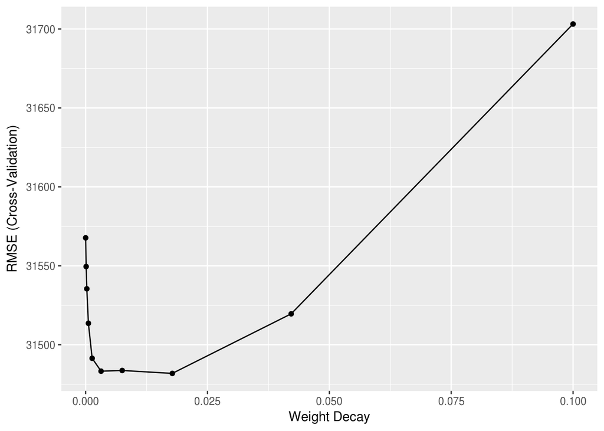

```r
ggplot(ridge)
```

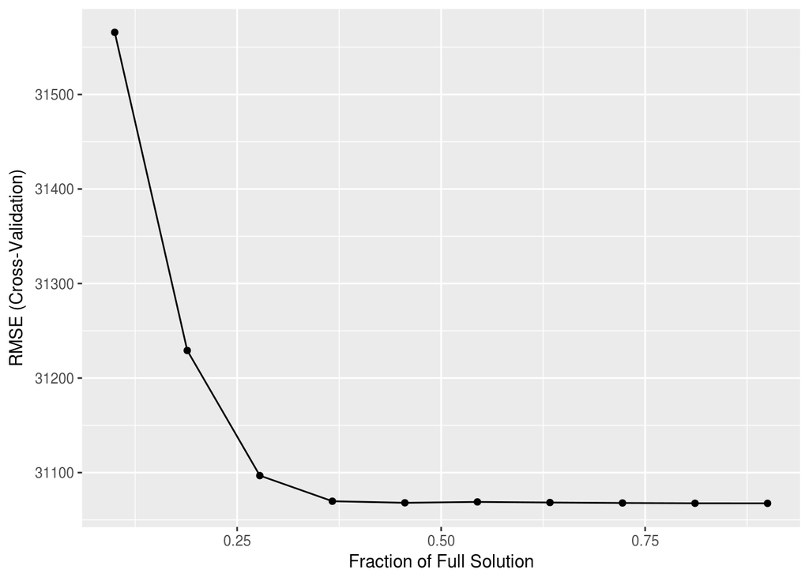

```r
ggplot(lasso)
```

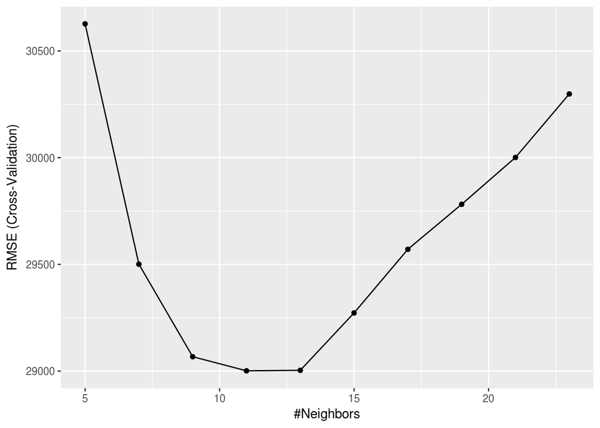

```r
ggplot(knn)
```

No modelo Lasso o parâmetro fraction varia entre 0 e 1, e a curva mostra que para um fraction igual a 0, RMSE é alto e a medida que ele aumenta o RMSE diminui, estabilizando por volta de fraction = 0,25.

No módelo KNN, a curva mostra que o RMSE vai melhorando a medida que se aumenta o número de vizinhos, mas proximo de 10 vizinhos, aumentar o número de vizinhos começa a piorar o modelo.

### 3. Quais as variáveis mais importantes segundo o modelo de regressão Ridge e Lasso? Variáveis foram descartadas pelo Lasso? Quais?

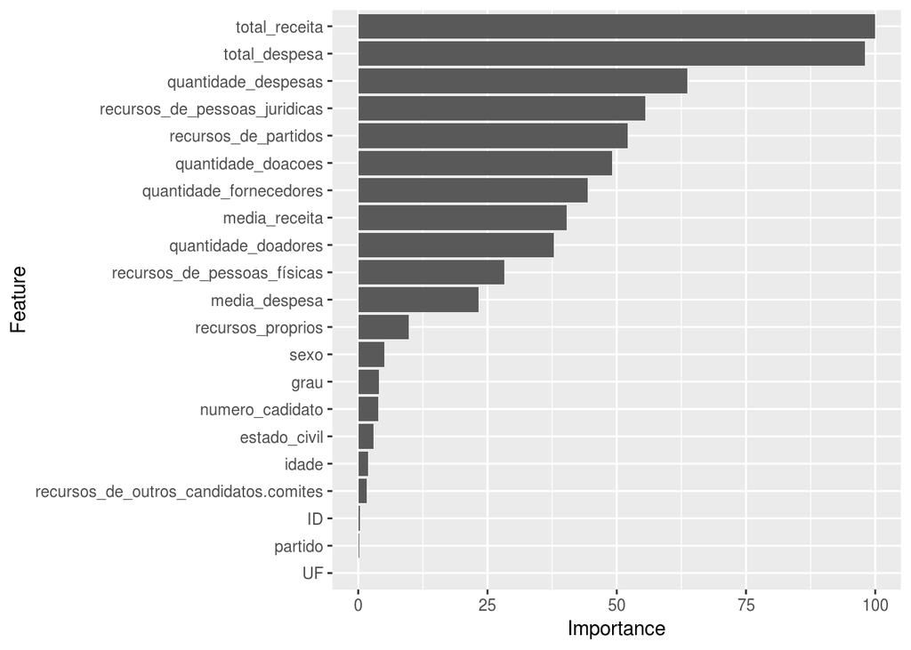

```r
ggplot(varImp(ridge))
```

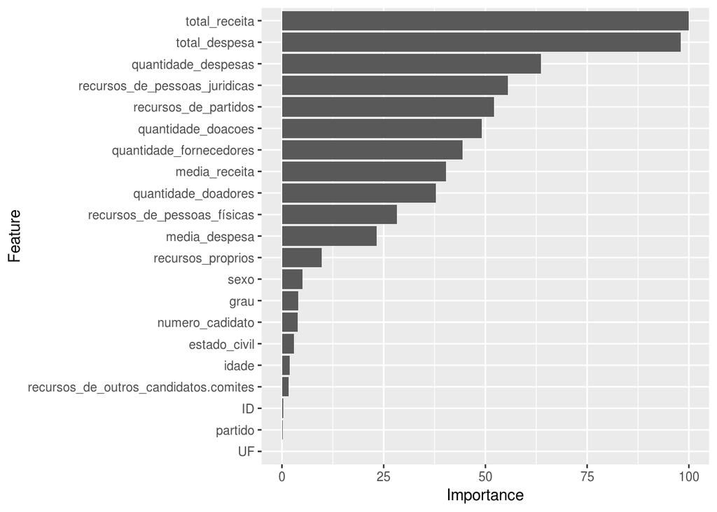

```r
ggplot(varImp(lasso))
```

Ambos os modelos tiveram a mesma ordem de import?ncia nas vari?veis mostradas no plot, e as vari?veis mais importantes para eles foram as vari?veis relacionadas a despesas, principalmente “total_receita” e “total_despesa”, o que seria de se esperar.

### 4. Re-treine o melhor modelo (usando os melhores valores de parâmetros encontrados em todos os dados, sem usar validação cruzada).

```r
bestK <- expand.grid(k = seq(13, 13, length=1))

best_model <- train(votos ~ .,
                    data = treino,
                    method = "knn",
                    tuneGrid = bestK)
```

### 5. Use esse último modelo treinado para prever os dados de teste disponíveis no challenge que criamos na plataforma Kaggle.

```r
submission_predict <- predict(best_model, teste)

for(i in 1:length(submission_predict)){
  print(submission_predict[i])
  submission$votos[i] = abs(submission_predict[i])
}
```

[output not shown]

[output cut: 1024 more lines]

```r
write.csv(submission, file = "RenatoEly_submission.csv", row.names = FALSE)
```